# Modelling Panther movements using moveHMM

Michael Li

09:51 06 July 2016

# Intro / Testing moveHMM

moveHMM is a lot faster than depmixS4. I am going to try to replicate the BIC plots via moveHMM.

```r
t1 <- proc.time()
library(moveHMM)
library(dplyr)
library(ggplot2)
dat <- read.csv("ArchivePantherData.csv")

timenames <- levels(dat$Time)
dat$Time <- factor(dat$Time,levels=timenames,labels=0:23)
```

moveHMM requires a *moveData* object for data frame. It takes the raw coordinates and computate the step length and turning angle using the *prepData* function. Note: we can’t simply feed out dataset in the fitting function, therefore, I class hack our dataframe.

```r
class(dat) <- c("moveData","data.frame")
```

Lets keep it consistent with our workflow and use one cat at a time. Note, we can feed all the cats in at once, but let’s save that for later.

```r
cat1 <- dat %>% filter(animal_id==1) %>% transmute(time=Time,
                                                    step=Steplength.m.,
                                                    angle=NA)
## err
class(cat1) <- c("moveData","data.frame")
```

Unlike depmixS4, we have to provide the starting parameters of each state. Let’s keep it simple and start with two states. We can’t fit univariate step-length HMMs, we can only fit multivariate step-length and turning angle HMMs. I can come up with three simple solution around this:

- change the turning angles to NA
- change the turning angles to 0 and give a very narrow VM distribution (ie. VM(0,1000)) for all states
- just ignore it and hope it will not *bias* the results

I like the first and second option the most.

```r
mu0 <- c(0,1)
sd0 <- c(0.1,0.5)
z0 <- c(0.1,0.2) ## not sure
step0 <- c(mu0,sd0,z0)

angleMean0 <- c(0,0)
kappa0 <- c(10000,10000)

angle0 <- c(angleMean0,kappa0)

hmm2s <- fitHMM(data=cat1,nbStates=2,stepPar0=step0,anglePar0=NULL,
                stepDist = "lnorm", angleDist = "none",
                formula = ~ 1)

hmm2s
```

[output not shown]

```r
## log-likelihood
hmm2s$mod$minimum
```

[output not shown]

# Panther BIC results

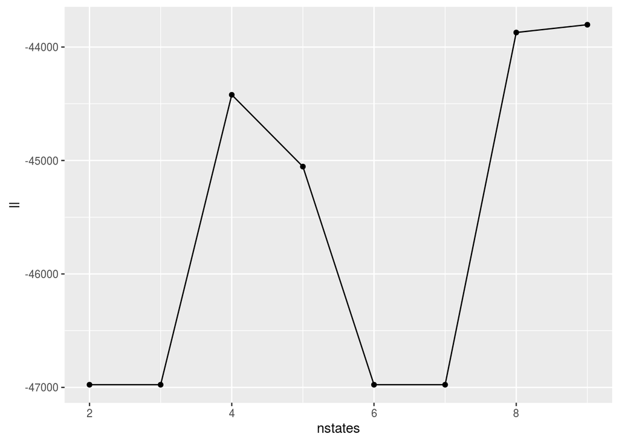

I did a bunch of BIC stuff too, but the free parameter calcuation is wrong (ie. not sure if I should include the 2n turning angle parameters and n zero-inflation parameters). You can see the problem by looking at the log-likelihood because it is not asymptotic. If you want to play around with it, you can try running states 2 to 5, fitting 7+ will take much more time.

```
##     user   system  elapsed
## 1422.364    0.304 1424.106
```

# Testing time-heterogeneous HMMs

```r
hmmsin <- function(n,dd){
  mu0 <- c(0:(n-1))
  sd0 <- rep(0.2,n)
  z0 <- rep(0.1,n)
  step0 <- c(mu0,sd0,z0)
  angle0 <- rep(c(0,10000),each=n)
  mod <- fitHMM(data=dd,nbStates=n,stepPar0=step0,anglePar0=NULL,
                stepDist = "lnorm", angleDist = "none",
                formula = ~ cos(2*pi*(as.numeric(time)-1)/24)+ sin(2*pi*(as.numeric(time)-1)/24))
  return(mod)
}

hmmsin2s <- hmmsin(2,cat1)
hmmsin3s <- hmmsin(3,cat1)
hmmsin4s <- hmmsin(4,cat1)

movell(hmm2s)
```

```
## [1] 46976.32
```

```r
movell(hmmsin2s)
```

```
## [1] 46976.32
```

```r
movell(hmm3s)
```

```
## [1] 46976.32
```

```r
movell(hmmsin3s)
```

```
## [1] 46976.32
```

```r
movell(hmm4s)
```

```
## [1] 44420.85
```

```r
movell(hmmsin4s)
```

```
## [1] 44222.49
```

I think something is wrong with 2 and 3 state models. Maybe that is the reason why the log-likelihood plot does not look asymptotic.